Go back to frontpage

# Assignment 3, Introduction to regression.

### Introduction:

In this assignment I am showing different approaches on how to apply regression methods to a chosen dataset. The dataset of my chosing is fault-lenghts measured from a Paris-Plaster experiment. This data is not the most ideal for showing cases of regression because of the scarsity of datapoints. However, it does showcase the oppurtunities avaliable for creating code evolving around regression methods. A lot of the work done in this assignment, has taken inspiration from the tutorials that has been done before starting the assignment. Group activities has also been performed, where discussing and sharing solutions has been key.

#### 1. From your own data, extract numerical values of two (preferably continuous) variables. The set of values you extract will be your original sample, and the number of values you extract will be the original sample size. You will be asked to do this again later in the exercise, choosing a different original sample size. Your sample will be composed of two variables, also known as a bivariate sample. If you have two variables you are interested in exploring the relationship between, that’s a bonus. If not, just explore a bit.

```python
#Importing the different python packages needed for plotting.
import pandas as pd
import numpy as np
import matplotlib.pyplot as plt
from numpy import random as rnd

#This libary is interesting, since its an open source data analysis libary for python. We will come back to this later in the assignment.
import seaborn as sns
```

```python
#Defining a variable named df, then sets it equal to the xlsx file that is read by using pandas libary.
df = pd.read_excel("FaultDisplacement.xlsx")
#Showing the variable to see what hides in it. This is a pandas dataframe with the data from the excel file converted.
df
```

|  | experiment_number | FaultNr | side_a | side_b |
| --- | --- | --- | --- | --- |
| 0 | 12-14 | 1 | 5.0 | 5.0 |
| 1 | 12-14 | 2 | 8.0 | 8.0 |
| 2 | 12-14 | 3 | 16.0 | 14.0 |
| 3 | 12-14 | 4 | 4.0 | 2.5 |
| 4 | 15-14 | 1 | 2.0 | 2.0 |
| 5 | 15-14 | 2 | 3.0 | 3.0 |
| 6 | 15-14 | 3 | 9.0 | 10.0 |
| 7 | 15-14 | 4 | 20.0 | 8.0 |
| 8 | 15-14 | 5 | 4.0 | 6.0 |
| 9 | 15-14 | 6 | 3.0 | 5.0 |
| 10 | 27-14 | 1 | 2.0 | 2.5 |
| 11 | 27-14 | 2 | 5.0 | 5.0 |
| 12 | 27-14 | 3 | 14.5 | 11.0 |
| 13 | 27-14 | 4 | 3.0 | 3.0 |
| 14 | 44-14 | 1 | 8.0 | 7.0 |
| 15 | 44-14 | 2 | 4.0 | 6.0 |
| 16 | 44-14 | 3 | 5.0 | 13.0 |
| 17 | 44-14 | 4 | 9.0 | 12.0 |
| 18 | 44-14 | 5 | 12.0 | 3.0 |
| 19 | 45-14 | 1 | 8.0 | 7.0 |
| 20 | 45-14 | 2 | 4.0 | 6.0 |
| 21 | 45-14 | 3 | 5.0 | 13.0 |
| 22 | 45-14 | 4 | 9.0 | 12.0 |
| 23 | 45-14 | 5 | 12.0 | 3.0 |
| 24 | 45-14 | 6 | 5.0 | 2.0 |
| 25 | 48-14 | 1 | 5.0 | 6.0 |
| 26 | 48-14 | 2 | 9.0 | 7.0 |
| 27 | 48-14 | 3 | 11.0 | 10.0 |
| 28 | 48-14 | 4 | 15.0 | 19.0 |
| 29 | 48-14 | 5 | 19.0 | 8.0 |

```python
#Sets the variable x to be a numpy array of the coloumn side_a in the dataset.
x = np.array(df['side_a'])
#Sets the variable y to be a numpy array of the coloumn side_b in the dataset.
y = np.array(df['side_b'])
```

# Methods

### 2. Make a scatter plot of the two variables and describe the plot.

In the plot beneath it can be seen how the fault lengths of side A has been plotted towards side B. The plot creates scatter plot values that are not perfectly aligned on a straight line, which makes the dataset suitable to use regression-methods on.

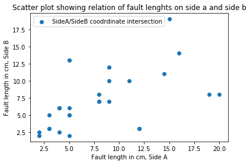

```python
#Using the matplotlib libary to plot the scatterplot of side_a against side_b.
plt.scatter(x,y, label='SideA/SideB coodrdinate intersection')

#Adding title, legend and axis labels.
plt.title('Scatter plot showing relation of fault lenghts on side a and side b')
plt.legend()
plt.xlabel('Fault length in cm, Side A')
plt.ylabel('Fault length in cm, Side B')
```

### 3. Perform a linear least-squares regression of one variable on the other, and plot the regression line. Describe the result.

```python
#Setting xic as the minimum value of x.
xic = x.min()
x = np.array(df['side_a'])
#Sets the variable y to be a numpy array of the coloumn side_b in the dataset.
y = np.array(df['side_b'])
#Setting n to the amount of datapoints in each column in the pandas dataframe. This is 30 values, based on the dataset.
n=df.shape[0]
'''Defining a function that takes 3 inputs(x,y,xic). This function will do calculations to return the slope and interception
   of the datapoints that is fed to the function.'''
def regr_coeff(x,y,xic):
    #Calculation of xx, yy and xy.
    xx = x*x
    yy = y*y
    xy = x*y

    #To be able to determine the interception of the datapoints and the slope, Sxx, Syy and Sxy needs to be calculated.
    Sxx = n*(xx.mean() -x.mean() * x.mean())
    Syy = n*(yy.mean() -y.mean() * y.mean())
    Sxy = n*(xy.mean() -x.mean() * y.mean())

    #From the values calculated above it is possible to determine the slope and intercept. These are then stored in the slope and icept variables.
    slope = Sxy/Sxx
    icept = np.mean(y) -slope*(np.mean(x) -xic)

    #The function returns the slope and icept variables as outputs.
    return [slope, icept]

print(icept)
```

```
4.321518774204414
```

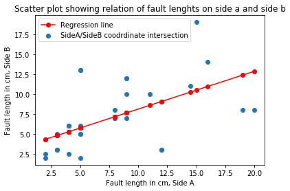

```python
#To be able to calculate the regression line the x values needs to be sorted into a numpy array that is in increasing order.
x_sorted = np.sort(x)

'''Defining a function named yline_from_coeff that calculates the regression line from the datapoints given as the 4 inputs(icept,
   slope,xarray,xic). icept and slope was calulated in the function defined above as the regr_coeff function.'''
def yline_from_coeff(icept,slope,xarray,xic):
    #yline variable is assigned is the regressionline. This is calculated by icept+slope*(xarray,xic)
    yline = icept + slope*(xarray-xic)
    #The function returns the regressionline.
    return yline

#Testing the function:
yline = icept + slope*(x_sorted -xic)

#Adding title, legend, labels and plotting the scatterplot and regressionline.
plt.title('Scatter plot showing relation of fault lenghts on side a and side b')
plt.xlabel('Fault length in cm, Side A')
plt.ylabel('Fault length in cm, Side B')
plt.scatter(x,y, label='SideA/SideB coodrdinate intersection')
plt.plot(x_sorted,yline, marker='o', color = 'red', label='Regression line')
plt.legend()
```

#### Describe the result.

As seen above the regression line has been plotted amoung the scatter plotted values. The regression line seems to be in the correct place as it is situated among the scatter values. With this we can further go at the task with confidence.

### 4. Describe the steps needed to compute bootstrap confidence intervals on a regression line.

To be able to compute bootstrap confidence intervals on a regression lines the following is needed: </br>

1. Functions for creating a regression line and regression coefficient is needed. From the regression_coeff function slope and intercept is provided as outputs. From the regression line function, the regression line is created. </br>
2. Further a for-loop needs to be defined. This goes from 0 to the amount of repretitions. Here bootstrap values from random integers created from the dataset needs to be collected. For every step in this loop the regression line and regr_coeff needs to be computed. </br>
3. The values are saved in a new array that is the same size as the original data sample. Further using np.quantile the end values are computed from the new array. This is then used to plot the values that is situated in the interval set.

### 5. Explain the difference between the original sample size, the bootstrap sample size, and the number of bootstrap samples

Original sample size: This is the amount of datapoints that are in the original dataset. </br> The bootstrap sample size: The boostrap sample size is amount sampled from the original dataset. A dataset may contain few values, but when we bootstrap it we resample smaller samples many times. </br> Number of boostrap samples: The amount of times we sample the samller dataset and use the sample to display the properties of the original sample.

# Results:

### 6. Compute bootstrap confidence intervals on the regression line, add them to the plot, and describe the result.

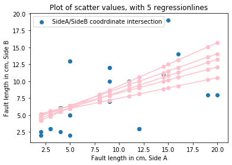

```python
#Defining a seed in random to get the same values each time this is computed.
rnd.seed(123)
#Defining a variable x_sorted as a numpy array that is sorting x in increasing order.
x_sorted = np.sort(x)
#Defining a index that is a numpy array with each indexing step in our dataset. This could also been attrived from our pandas dataframe.
index = np.linspace(0,29,30).astype(int)
#Variable reps defines how many steps the bootstrap is to take.
reps = 5

#Defining a for-loop that runs from 0 to amount of repetitions(reps).
for i in range(0,reps):
    #Defining a variable boot that is equal to random numbers generated in the dataset.
    boot = rnd.choice(index, n, replace = True)
    #Setting xr variable to x amount of boot.
    xr = x[boot]
    #Setting yr variable to y amount of boot.
    yr = y[boot]
    #Calculating slope and icept from the function created earlier.
    (slope, icept) = regr_coeff(xr,yr,xic)
    #Calculating the regressionline from the function 'yline_from_coeff' that was created earlier.
    new_yline = yline_from_coeff(icept, slope, x_sorted,xic)
    #Plotting the regressionlines and the scatter points.
    plt.plot(x_sorted,new_yline, marker = 'o', color = 'pink')

#Plotting the scatter plot.
plt.scatter(x,y, label='SideA/SideB coodrdinate intersection')
#Showing legend.
plt.legend()
#Adding title:
plt.title('Plot of scatter values, with 5 regressionlines')
#Adding axis-labels.
plt.xlabel('Fault length in cm, Side A')
plt.ylabel('Fault length in cm, Side B')
```

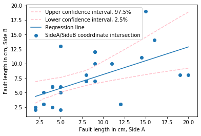

```python
#Defining amount of reps.
reps = 100
#defining a variable named arrayx, that is set to an array with the same size, but each value is set to zeros.
array_for_values = np.zeros([reps,n])
#Defining a for-loop that is set to run from 0 to the amount of reps.
for i in range(0, reps):
    #Defining a variable boot that is equal to random numbers generated in the dataset.
    boot = rnd.choice(index, n, replace = True)
    #Setting xr variable to x amount of boot.
    xr = x[boot]
    #Setting yr variable to y amount of boot.
    yr = y[boot]
    #Calculating slope and icept from the function created earlier.
    (slope, icept) = regr_coeff(xr,yr,xic)
    #Calculating the regressionline from the function 'yline_from_coeff' that was created earlier.
    new_yline = yline_from_coeff(icept, slope, x_sorted,xic)
    #adding the values to arrayx from the function new_yline to fill it up with values calculated.
    array_for_values[i,:] = new_yline[:]

#Setting quantile values(confidence interval end lines). To be plotted.
upper_boot = np.quantile(array_for_values, 0.975, axis =0)
lower_boot = np.quantile(array_for_values, 0.025, axis =0)

#Plotting the confidence interval end lines.
plt.plot(x_sorted, upper_boot, color='pink',linestyle ='dashed',label='Upper confidence interval, 97.5%')
plt.plot(x_sorted, lower_boot, color='pink',linestyle ='dashed', label = 'Lower confidence interval, 2.5%')

#Plotting the regression line.
plt.plot(x_sorted,yline, label='Regression line')

#Plotting the scatter plot.
plt.scatter(x,y, label='SideA/SideB coodrdinate intersection')

#Adding title, axis-labels
plt.xlabel('Fault length in cm, Side A')
plt.ylabel('Fault length in cm, Side B')
plt.legend()
```

```python
np.shape(index)
```

```
(30,)
```

### Describe the result.

5 regression lines has been plotted. This is correct considering we have 5 reps in the for-loop. The regression lines match the data and has different slope angles as well as have different start/end points. When looking at the result further below with the confidence interval these regression lines fall within this. The 2. plot looks good compared to the plot done in tutorial 2. Some of the scatterpoints fall within the confidence intervall and some fall outside the confidence interval. *

# Discussion:

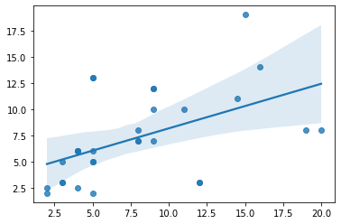

```python
sns.regplot(x, y, n_boot=100, ci=97.5)
plt.show()
```

### 7. Compute the correlation coefficient, and comment on its value.

```python
'''Defining a function that is used to calculate the correlation coefficient, this code is outlined above,
   but now turned into a function. This could further be used to apply this several times if needed.'''
def compute_correlation_coefficient():
    #Calculation of xx, yy and xy.
    xx = x*x
    yy = y*y
    xy = x*y

    #To be able to determine the interception of the datapoints and the slope, Sxx, Syy and Sxy needs to be calculated.
    Sxx = n*(xx.mean() -x.mean() * x.mean())
    Syy = n*(yy.mean() -y.mean() * y.mean())
    Sxy = n*(xy.mean() -x.mean() * y.mean())

    #Setting a variable named R to be equal to the equation that is needed to compute the correlation coefficient.
    r = Sxy/np.sqrt(Sxx*Syy)
    return r
#Printing the correlation coefficient.
print('The correlation coefficient is r = ',compute_correlation_coefficient())
```

```
The correlation coefficient is r =  0.503918203354853
```

The correlation coefficient is 0.5, this means that it is possible to compute the regression line. However, not all values are located on the regressionline. This means that the two variables are not perfectly correlated.

### 8. What do you expect will happen to the confidence intervals if you went back and created a new original sample (see point 1) using a substantially different sample size (i.e., you extract a different number of values from your data)? Discuss in your group.

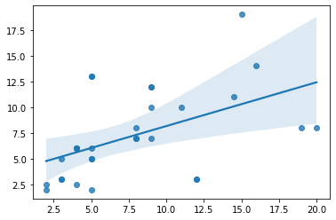

```python
scat=sns.regplot(x,y, n_boot=10000, ci=97.5)
```

### 9. What do you expect will happen to the confidence intervals if you keep the original sample size fixed, but you change substantially the size of each bootstrap sample (the number of observations you re-sample from your original sample)? Discuss in the group.

I would expect the confidence interval to increase in width on the plot. This is because we would get a more accurate edge represenation in the plot.

### 10. Resampling methods are based on resampling a sample many times. To compute bootstrap confidence intervals, the number of bootstrap samples (i.e. how many times we draw a bootstrap sample) should ideally be a very large number. Why is this? What fundamental law are we relying on here? Discuss in your group.

We are relying on the law of large numbers here. To compute bootstrap confidence intervals the number of bootstrap samples should be a large number to incease the accuracy of our analysis.

### 11. Create a new original sample from your data, using a substantially different sample size. Recompute bootstrap confidence intervals on the regression line on this new original sample.Discuss the result. Is it consistent with your expectation?

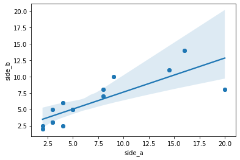

```python
sidea = df['side_a']
sideb = df['side_b']
new_sample_sidea = sidea.head(15)
new_sample_sideb = sideb.head(15)

plt.scatter(new_sample_sidea,new_sample_sideb)
new_sample_scatter=sns.regplot(new_sample_sidea,new_sample_sideb, n_boot=100, ci=97.5)
```

### 12. Recompute bootstrap confidence intervals on the regression line, keeping the original sample size fixed, but using a substantially different bootstrap sample size. Discuss the result. Is it consistent with your expectation?

Considering we run the bootstrap more times, we would expect a more accurate result since the outermost values are better computed. This is consistent with the my expectation of it being more accurate. By comparing what we did in task 11. this seems to be correct.

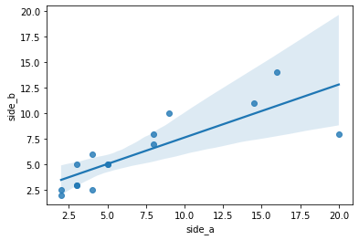

```python
recomputed_new_sample_scatter=sns.regplot(new_sample_sidea,new_sample_sideb, n_boot=1000, ci=97.5)
```

# References:

Seaborn python libary: https://seaborn.pydata.org/

Tutorial 1 & 2 from GEOV302, Mitt.uib.no